# INTRODUCCIÓN AL MANEJO DE DATOS Y PROGRAMACIÓN EN R

# APENDICE 1: COERCIÓN

### Qué es coerción?

- Conversión entre clases atómicas (e.g., entre `character` y `factor`, entre `numeric` e `integer`, etc.)
- El objetivo es preservar el símbolo/contenido, pero permitir otro tipo de operaciones con el cambio de clase
- Existen dos tipos: Implícita y explícita. La primera, llevada a cabo por el sistema, y la segunda, declarada por el usuario

### Coerción explícita

- Se logra por medio de las funciones `as.CLASS()`, siendo CLASS cualquiera de las clases atómicas ya conocidas.
- Generalmente útil cuando los métodos aplicados a objetos solo soportan alguna clase particular, pero pueden operar sobre los mismos símbolos.
- El símbolo NO necesariamente lleva una clase explícita. Por ejempĺo, el número `1` puede ser de cualquier clase, aún `logical`:

```r
cla <- 1
as.character(cla)
```

```
[1] "1"
```

```r
as.integer(cla)
```

```
[1] 1
```

```r
as.numeric(cla)
```

```
[1] 1
```

```r
as.logical(cla)
```

```
[1] TRUE
```

### Coerción explícita: Entre numeric e integer

```r
float <- 5.0000
print(float)
```

```
[1] 5
```

```r
class(float) # Qué clase tiene el objeto float?
```

```
[1] "numeric"
```

```r
integer <- as.integer(float) # Coerción de clase numeric a integer
print(integer)
```

```
[1] 5
```

```r
class(integer) # Qué clase tiene el objeto integer?
```

```
[1] "integer"
```

### Coerción explícita: Entre character y factor

```r
string <- c("a", "b", "b", "b", "a", "c", "d", "c", "a", "e")
print(string)
```

```
 [1] "a" "b" "b" "b" "a" "c" "d" "c" "a" "e"
```

```r
class(string)
```

```
[1] "character"
```

```r
fact <- as.factor(string)
print(fact)
```

```
 [1] a b b b a c d c a e
Levels: a b c d e
```

```r
class(fact)
```

```
[1] "factor"
```

### Coerción explícita: En general...

Cuando tiene sentido…

```r
numeros <- 0:3
as.numeric(numeros)
```

```
[1] 0 1 2 3
```

```r
as.logical(numeros)
```

```
[1] FALSE  TRUE  TRUE  TRUE
```

```r
as.character(numeros)
```

```
[1] "0" "1" "2" "3"
```

Cuando no tiene sentido…

```r
letras <- c('a', 'b', 'c')
as.numeric(letras)
```

```
[1] NA NA NA
```

```r
as.logical(letras)
```

```
[1] NA NA NA
```

```r
as.complex(letras)
```

```
[1] NA NA NA
```

### Coerción implícita

- Ocurre cuando mezclamos objetos de diferentes clases en un objeto que solo puede contener elementos de la misma clase. Por ejemplo, si aplicamos `c()` sobre elementos de clase `character` y `numeric`, cuál es la clase del vector resultante?

```r
difcl <- c(1, 2, 'tres', 'cuatro', 5, 'seis')
class(difcl)
```

```
[1] "character"
```

```r
as.numeric(c('b', 'c', 4, 'd'))
```

```
[1] NA NA  4 NA
```

# PAQUETERÍA Y POTENCIAL GRÁFICO

### ¿Qué son los paquetes?

- Software (i.e., funciones) escritas para llevar a cabo tareas relacionadas
- TODOS de libre acceso
- La mayoría escritos en `R`, pero varios en `C`, `C++` o `FORTRAN`
- Nivel pro en `R`. Si se ha aprendido a programar y se han generado funciones útiles para alguna tarea que valga la pena publicar, tal vez sea buena idea someter un nuevo paquete. La inmensa mayoría de los usuarios jamás llega a este punto

### ¿Qué son los paquetes?

- R + 4 paquetes

[figure not shown]

- R + 6 paquetes

[figure not shown]

- R + 12 paquetes

[figure not shown]

- R + N paquetes

[figure not shown]

### ¿Dónde se encuentran?

- En el “Comprehensive R Archive Network”, el repositorio oficial de `R` (http://cran.r-project.org/)
- R ha evolucionado de manera increíble en cuanto a soporte adicional de paquetería.

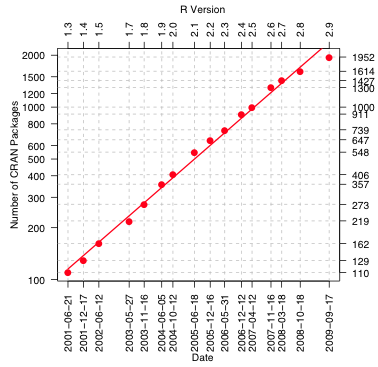

### Ejemplos de paquetes

- `ggplot2`. Sistema avanzado de graficación
- `vegan`. Paquete para análisis ecológicos
- `ddplyr`. Paquete de herramientas para manipulación de datos
- `xlsx`. Paquete para importar/exportar datos entre `R` y MS Excel

### Instalación

- `install.packages()` Función estándar para instalar directamente de CRAN
- `devtools::install_github()` Función adicional para instalar de github.com. Requiere tener instalado el paquete `devtools`

```r
install.packages("vegan") #El nombre del paquete va entre comillas

library(devtools) # Cargar devtools para usar install_github
install_github('droglenc/FSA') # Esta función puede usarse con un solo argumento con el formato "usuario/repositorio"
```

### Cargando paquetes

- La función `library()` se encarga de cargar los paquetes que necesitemos

```r
library(vegan) #Al cargar el paquete NO usar comillas
library(devtools)
library(FSA)
```

- Los paquetes pueden tener dependencias, es decir, requerir paquetes adicionales para funcionar. Siempre descargar e instalar el paquete Y sus dependencias
- Una vez cargado el paquete, se puede hacer uso de sus funciones
- En este ejemplo, la función `specaccum()` del paquete `vegan`, solo funcionará después de cargar el paquete

### Gráficos en R

- `R` tiene opciones extensas de graficación, desde sistemas sencillos como `base` a algunos más sofisticados como `lattice` o `ggplot2`
- Cada sistema de gráficos de R tiene sus pros y sus contras, y trabaja mejor bajo condiciones específicas
- La graficación en `R` es un arte complejo y requiere mucho esfuerzo para ser dominado. Cada tipo de gráfica puede requerir un sistema gráfico diferente

### Gráficos en R

- Hay dos pasos básicos que son más evidentes en `base`: Generación del gráfico y anotación. EL sistema `lattice` es diferente pues el gráfico se genera con una sola llamada de función.
- En contraste, `ggplot2` es un sistema que funciona con ambos procedimientos, generación de gráficos y anotación, pero también puede generar un gráfico completo con una sola llamada de función como `lattice`.

### Gráficos en R: base

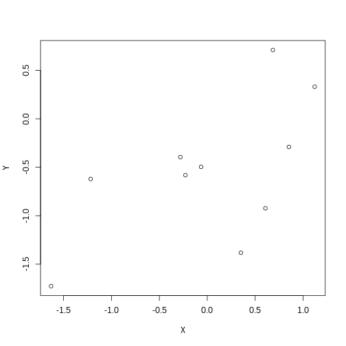

```r
plot(Y ~ X, data = datos) # Gráfico básico
```

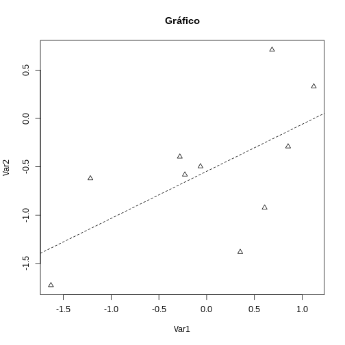

```r
par(lty = 2, pch = 2)
plot(Y ~ X, data = datos, main = "Gráfico", xlab = "Var1", ylab = "Var2")
abline(lmod)
```

### Gráficos en R: lattice

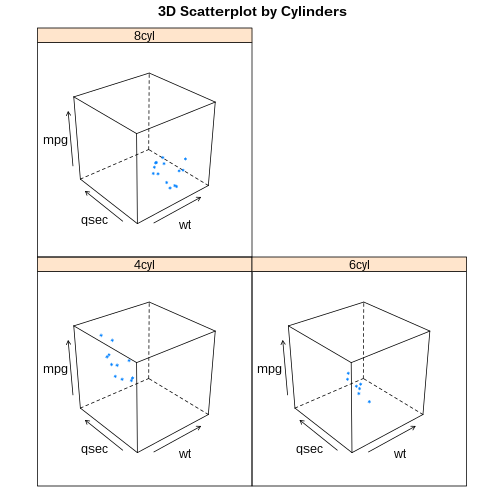

```r
library(lattice)
cloud(mpg~wt*qsec|cyl.f, main="3D Scatterplot by Cylinders")
```

### Gráficos en R: ggplot2

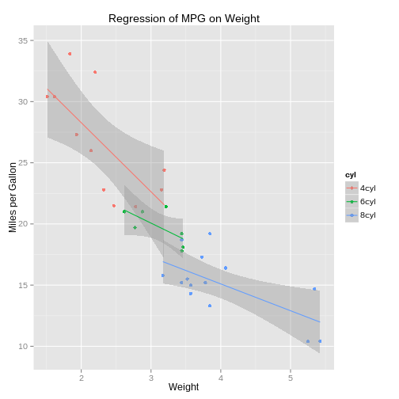

```r
library(ggplot2)

qplot(wt, mpg, data=mtcars, geom=c("point", "smooth"), method="lm", formula=y~x, color=cyl, main="Regression of MPG on Weight", xlab="Weight", ylab="Miles per Gallon")
```

### Gráficos en R: ggplot2

- Ejemplo de código necesario para generar un grafico con `ggplot2`

```r
# Creación del objeto que alojará las capas del gráfico
p <- qplot(hp, mpg, data=mtcars, shape=am, color=am, facets=gear~cyl, main="Scatterplots of MPG vs. Horsepower", xlab="Horsepower", ylab="Miles per Gallon")

# Adición de fondo blanco y líneas de separación negras
p + theme_bw()

# Cambios en el color y el tamanho de los rótulos, adición de leyenda
p + theme(axis.title=element_text(face="bold.italic",
   size="12", color="brown"), legend.position="top")
```

### Gráficos básicos: Histograma

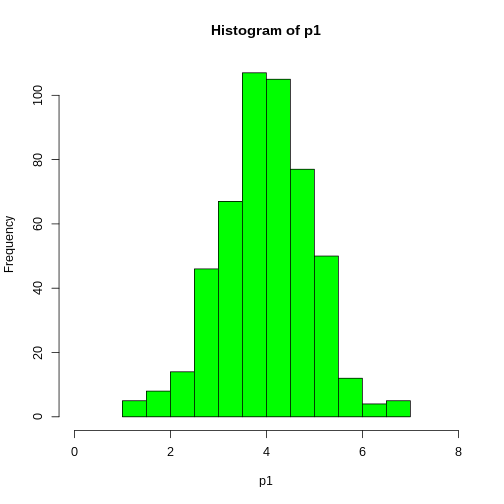

### Gráficos básicos: Boxplot

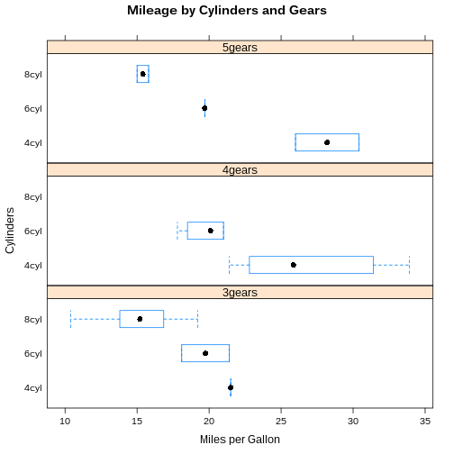

### Gráficos básicos: Diagrama de barras

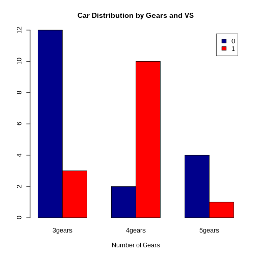

### Gráficos básicos: Diagrama de dispersión + Regresión

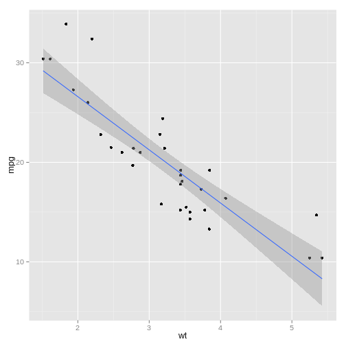

### Gráficos básicos: Gráficos de densidad (Distribuciones)

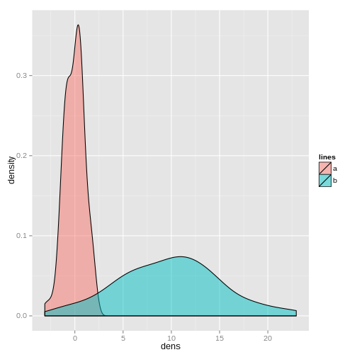

### Gráficos básicos: Dendrogramas

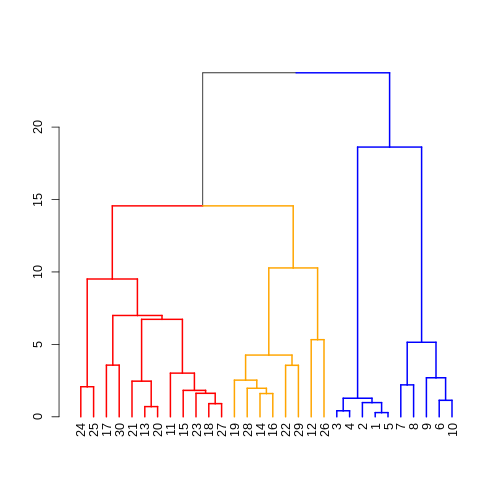

### Gráficos básicos: Heatmaps

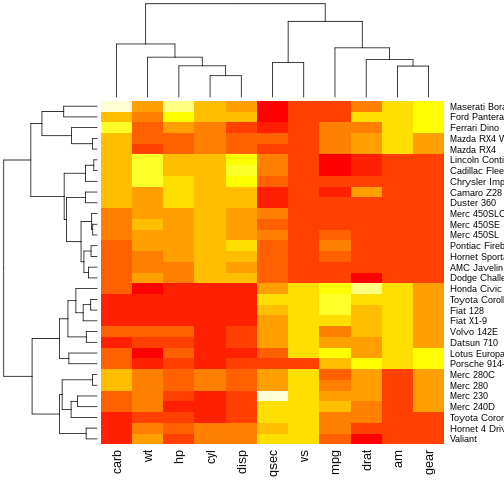